# Getting Started

Joshua L Eubanks

# Installing and Using Packages

For an example, let’s install the package swirl:

```r
install.packages("swirl")
```

This command pulls and stores the package into your library. If you want to actually use it, you must pull it from your library:

```r
library(swirl)
```

## Help

swirl is an important package for beginners because it will show you how to do the basics step by step.

Also if you need help with any commands, you can put a question mark before a command to understand how to use it.

`?merge`

Search by keywords: `??matrix` `??"identity matrix"`

# Basic commands

R can be used as a basic calculator

```r
5 + 2
```

```
## [1] 7
```

There will be times that you wish to store certain calulations for future use. To store this calculation you would need to assign it to an object.

```r
LuckyNumber <- 5 + 2
```

You may want to call that object later:

```r
UnluckyNumber <- LuckyNumber + 6

UnluckyNumber
```

```
## [1] 13
```

## Creating vectors and Matrices

```r
v1 <- 1:5
v2 <- c(1,1,3,3,3,3.22225,4,5, NA)
v3 <- c("Bill", "Stacey", "John")

matrix <- matrix(1:100, nrow = 10)
```

## Descriptive Statistics

```r
mean(v1)
```

```
## [1] 3
```

```r
median(v1)
```

```
## [1] 3
```

```r
sd(v1)
```

```
## [1] 1.581139
```

```r
range(v1)
```

```
## [1] 1 5
```

One thing to note is that observations that are NA will not be counted as zero, it will cause issues:

```r
mean(v2)
```

```
## [1] NA
```

You can fix this by dropping NAs:

```r
mean(v2, na.rm = TRUE)
```

```
## [1] 2.902781
```

If you want to understand the structure of your object:

```r
class(UnluckyNumber)
```

```
## [1] "numeric"
```

```r
class(v1)
```

```
## [1] "integer"
```

```r
class(v3)
```

```
## [1] "character"
```

## Example

```r
x <- c(23,37,32,41,51)
y <- c(27,27,24,28,31)
```

The formula for the correlation coefficient **(r)** is:

$$r = \frac{n\Sigma xy - \Sigma x \Sigma y}{\sqrt{[n\Sigma x^{2} - (\Sigma x)^2]\cdot[n\Sigma y^{2} - (\Sigma y)^2]}}$$

Let’s collect all those variables for the formula:

```r
sum_x <- sum(x)


sum_y <-sum(y)

xy <- x * y
sum_xy <-sum(xy)

y_sq <- y * y
sum_y2 <-sum(y_sq)

x_sq <- x * x
sum_x2 <-sum(x_sq)

n <- 5
```

Now run that formula:

```r
r <- ((n * sum_xy) - (sum_y * sum_x)) / (sqrt((n * sum_x2 - (sum_x)^2) * (n * sum_y2-(sum_y)^2)))
r
```

```
## [1] 0.7219838
```

# Dataframes

A simpler solution to the previous example would be:

```r
data_frame <- data.frame(x,y)
cor(data_frame)
```

```
##           x         y
## x 1.0000000 0.7219838
## y 0.7219838 1.0000000
```

# Linear regression

```r
simpleRegression <- lm(y ~ x, data_frame)
summary(simpleRegression)
```

```
##
## Call:
## lm(formula = y ~ x, data = data_frame)
##
## Residuals:
##       1       2       3       4       5
##  2.0042 -0.4348 -2.5638 -0.1317  1.1262
##
## Coefficients:
##             Estimate Std. Error t value Pr(>|t|)
## (Intercept) 20.98891    3.65887   5.736   0.0105 *
## x            0.17421    0.09639   1.807   0.1684
## ---
## Signif. codes:  0 '***' 0.001 '**' 0.01 '*' 0.05 '.' 0.1 ' ' 1
##
## Residual standard error: 2.005 on 3 degrees of freedom
## Multiple R-squared:  0.5213, Adjusted R-squared:  0.3617
## F-statistic: 3.266 on 1 and 3 DF,  p-value: 0.1684
```

# Working with a real dataset

```r
data <- mtcars

mean(data$mpg)
```

```
## [1] 20.09062
```

```r
range(data$cyl)
```

```
## [1] 4 8
```

```r
class(data$am)
```

```
## [1] "numeric"
```

```r
summary(mtcars)
```

```
##       mpg             cyl             disp             hp
##  Min.   :10.40   Min.   :4.000   Min.   : 71.1   Min.   : 52.0
##  1st Qu.:15.43   1st Qu.:4.000   1st Qu.:120.8   1st Qu.: 96.5
##  Median :19.20   Median :6.000   Median :196.3   Median :123.0
##  Mean   :20.09   Mean   :6.188   Mean   :230.7   Mean   :146.7
##  3rd Qu.:22.80   3rd Qu.:8.000   3rd Qu.:326.0   3rd Qu.:180.0
##  Max.   :33.90   Max.   :8.000   Max.   :472.0   Max.   :335.0
##       drat             wt             qsec             vs
##  Min.   :2.760   Min.   :1.513   Min.   :14.50   Min.   :0.0000
##  1st Qu.:3.080   1st Qu.:2.581   1st Qu.:16.89   1st Qu.:0.0000
##  Median :3.695   Median :3.325   Median :17.71   Median :0.0000
##  Mean   :3.597   Mean   :3.217   Mean   :17.85   Mean   :0.4375
##  3rd Qu.:3.920   3rd Qu.:3.610   3rd Qu.:18.90   3rd Qu.:1.0000
##  Max.   :4.930   Max.   :5.424   Max.   :22.90   Max.   :1.0000
##        am              gear            carb
##  Min.   :0.0000   Min.   :3.000   Min.   :1.000
##  1st Qu.:0.0000   1st Qu.:3.000   1st Qu.:2.000
##  Median :0.0000   Median :4.000   Median :2.000
##  Mean   :0.4062   Mean   :3.688   Mean   :2.812
##  3rd Qu.:1.0000   3rd Qu.:4.000   3rd Qu.:4.000
##  Max.   :1.0000   Max.   :5.000   Max.   :8.000
```

# Linear Regression and Prediction

```r
regression <- lm(mpg ~ cyl + disp + hp + factor(am), data)

summary(regression)
```

```
##
## Call:
## lm(formula = mpg ~ cyl + disp + hp + factor(am), data = data)
##
## Residuals:
##     Min      1Q  Median      3Q     Max
## -4.6537 -2.2037 -0.3065  1.5581  6.0095
##
## Coefficients:
##              Estimate Std. Error t value Pr(>|t|)
## (Intercept) 30.476440   2.865526  10.636 3.72e-11 ***
## cyl         -0.834497   0.757091  -1.102   0.2801
## disp        -0.007745   0.010716  -0.723   0.4761
## hp          -0.032962   0.015614  -2.111   0.0442 *
## factor(am)1  3.445269   1.453855   2.370   0.0252 *
## ---
## Signif. codes:  0 '***' 0.001 '**' 0.01 '*' 0.05 '.' 0.1 ' ' 1
##
## Residual standard error: 2.831 on 27 degrees of freedom
## Multiple R-squared:  0.8079, Adjusted R-squared:  0.7794
## F-statistic: 28.38 on 4 and 27 DF,  p-value: 2.54e-09
```

Making a prediction about the mpg for a particular car:

```r
predict(regression,data.frame(cyl = 6, disp = 160, hp = 93, am = 1),level = .95, interval="confidence")
```

```
##       fit      lwr      upr
## 1 24.6101 21.92684 27.29336
```

## Pulling stuff from regression

```r
Beta_1 <- summary(regression)$coefficients[2]
SE_Beta_3 <- coef(summary(regression))[4, 2]
```

# Anova

```r
regression_reduced <- lm(mpg ~ cyl + disp + hp, data)
anova(regression_reduced, regression)
```

```
## Analysis of Variance Table
##
## Model 1: mpg ~ cyl + disp + hp
## Model 2: mpg ~ cyl + disp + hp + factor(am)
##   Res.Df    RSS Df Sum of Sq      F  Pr(>F)
## 1     28 261.37
## 2     27 216.37  1    45.002 5.6157 0.02521 *
## ---
## Signif. codes:  0 '***' 0.001 '**' 0.01 '*' 0.05 '.' 0.1 ' ' 1
```

# Graphing

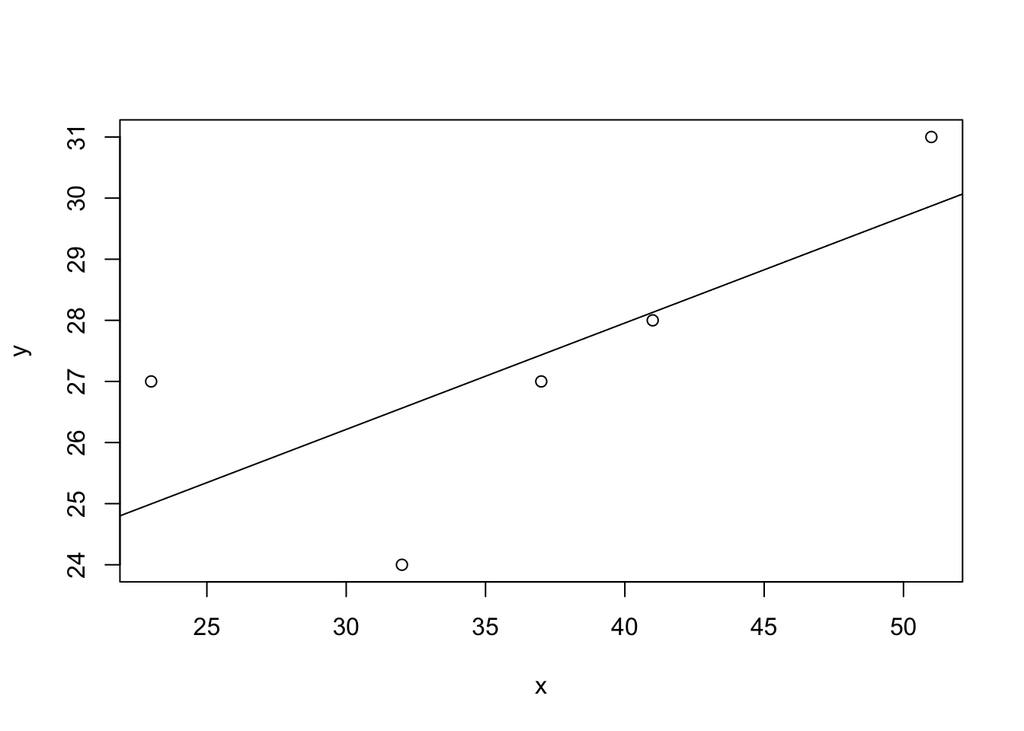

```r
plot(x, y)
abline(simpleRegression)
```

For a dotted regression line, all you need to do is change the arguement: `abline(regression, lty=2)`

## Using ggplot2

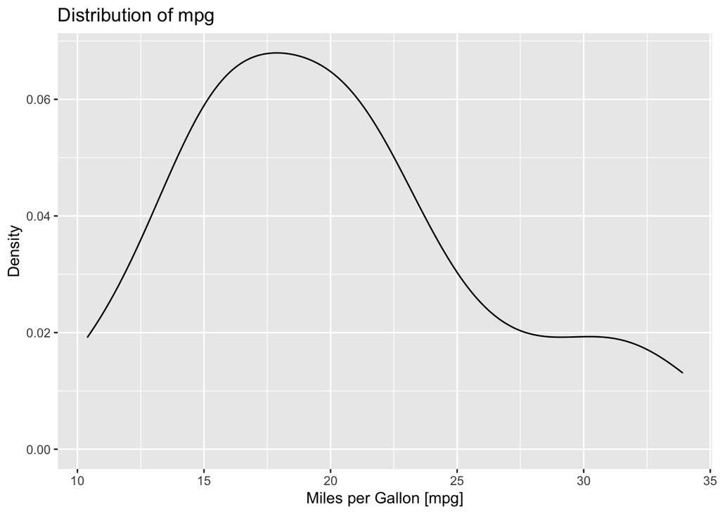

```r
library(ggplot2)
qplot(mpg, data=data, geom="density", alpha=I(.5),
      main="Distribution of mpg", xlab="Miles per Gallon [mpg]",
      ylab="Density")
```

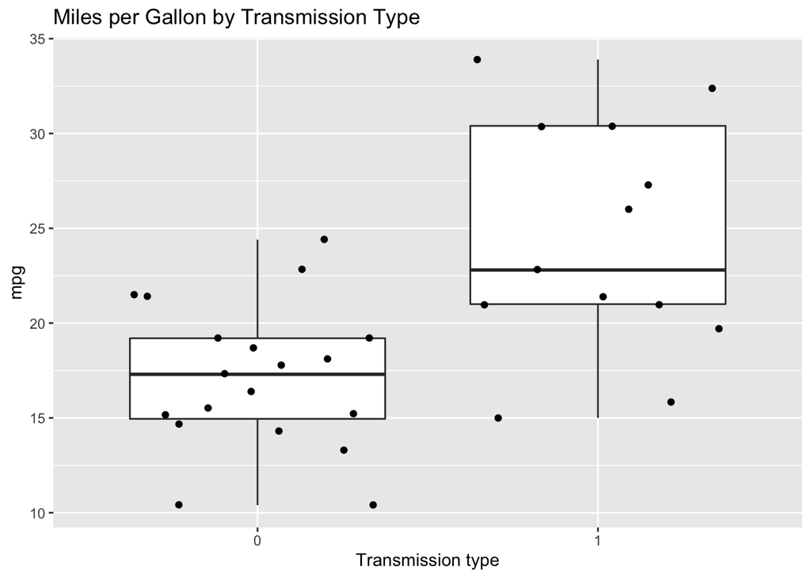

```r
qplot(factor(am), mpg, data=data, geom=c("boxplot", "jitter"),
       main="Miles per Gallon by Transmission Type",
      xlab="Transmission type", ylab="mpg")
```

## Barplots

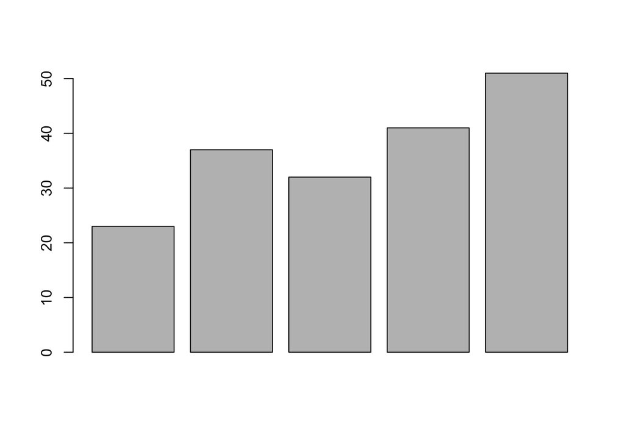

```r
barplot(x)
```